# ml_projeto

## MAC0460 - Final Project

Members:

- Luã Nowacki Scavacini Santilli - NUSP 11795492
- João Vitor Magalhães Leite - NUSP 11849414

### Summary

To simplify some processes, we decided to use the open-source library PyTorch, which has useful tools for deep learning. Cifar-10 data can be downloaded through the library datasets module.

In possession of the dataset, initial procedures were performed. First, converting the format of the images through the transforms module included in the library, and then the normalization of the converted images. The normalization step was introduced given the behaviour of activation and loss functions. In other words, this functions perform better if your input is in the range [-1, +1]

In terms of implementation we created a class named CIFAR10TrainingModel. It has among others generic methods for loading, transforming and training a model. It's implemented on the cifar10_model.py file. The models used are implemented in the models.py file, and designed according to the PyTorch specification

The first model we trained was a simple neural network. With this approach we were able to achieve an accuracy on the validation data of around 40%. We them perceived that by using increasing the number of iterations on the the process we were overfitting the training model, that is, the accuracy on the training set was increasing, but the accuracy on the validation model was not improving or not improving at the same rate.

This distance between the validation accuracy and the training accuracy was our major way of identifying when our approach was overfitting the training data.

After this baseline we decided to try using a more sophisticated approach with an estabilshed model for convolutional neural networks, the LeNet model. Just by using this new model we were able to reach an accuracy of around 70% on the validation data. But after that we were overfitting.

This made us think of regularization techniques to try to prevent overfitting. Our approach was to use data augmentation. This made the accuracy on the validation set curve follow much closer the accuracy on the training one. But prevented the network from learning on the training set.

With this approach we reached the level of accuracy of around 63%

After this approach we tried using transfer learning through AlexNet. PyTorch makes it easy to use the ImageNet weights. Even though we were able to modify the model to the Cifar10 dataset, the computational perfomance requirements to train just the neural network portion of the AlexNet proved to be too high for our setup.

After this exploration we settled on using the LeNet model without image augmentation for the test dataset. And with this we achieved an accuracy of 73%

```python
# Libray imports
%matplotlib inline
from matplotlib import pyplot as plt
import numpy as np
import torch
import torch.nn.functional as F
from torchvision import datasets
from torchvision import transforms
import torch.optim as optim
import torch.nn as nn

torch.set_printoptions(edgeitems=2)
torch.manual_seed(420)
```

```
<torch._C.Generator at 0x1fb5c2068f0>
```

### The Cifar10 dataset

The Cifar10 dataset consists of 50000 images for tranining and 10000 images for testing. The images are split in 10 different classes. They are in rgb and their size is 32x32

The dataset module of PyTorch is capable of download both sets.

```python
data_path = '../data/'
cifar10 = datasets.CIFAR10(data_path, train=True, download=True)
```

```
Files already downloaded and verified
```

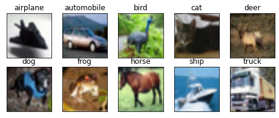

```python
fig = plt.figure(figsize=(8,3))
num_classes = 10
for i in range(num_classes):
    ax = fig.add_subplot(2, 5, 1 + i, xticks=[], yticks=[])
    ax.set_title(class_names[i])
    img = next(img for img, label in cifar10 if label == i)
    plt.imshow(img)
plt.show()
```

### Finding the mean and std of the training dataset

The images now have different intensity distributions. We would like that they would be normalized. This way our model could better associate a intensity, or relation of intensities with a given feature. Besides, activation and loss functions tend to perform better when the input is in the range [-1, +1].

To normalize the images we are going to iterate over the entire training dataset, and find the mean and std value for each color channel. Then we are going to normalize the entire training set according to this values. And we also need to trasform the images to tensors. This implies changing the dimensions of an image of 32x32x3, the format expected by utilities like plt.imshow to display images, to the format 3x32x32, the format that PyTorch expects for standard image training.

In terms of implementation, we already baked those numbers into the Cifar10TrainingModel class. But we repeat the implementation here for presentation purposes.

```python
tensor_cifar10 = datasets.CIFAR10(data_path, train=True, download=False,
                              transform=transforms.ToTensor())
imgs = torch.stack([img_t for img_t, _ in tensor_cifar10], dim=3)
imgs.shape
```

```
torch.Size([3, 32, 32, 50000])
```

```python
imgs.view(3, -1).mean(dim=1)
```

```
tensor([0.4914, 0.4822, 0.4465])
```

```python
imgs.view(3, -1).std(dim=1)
```

```
tensor([0.2470, 0.2435, 0.2616])
```

### Partitioning the dataset

We are going divide the dataset into 4 distinct categories.

The first category consists of 40000 images. They will be used for training.

The second is a category of 100 images. This category will be used for the overfitting test.

The third category consists of 10000-100 images to be used for validation.

And the fourth and final category will be untouched throught the process. And is only going to be used once. For the final test after the model selection.

### The overfitting test

The overfitting test is an implementation practice. It consists of overtraining your model on a single batch to see if your model has enough capacity to model a very simple subsection of your data. It is also very usefull to catch implementation bugs. We decided to leave the implementation of the overfitting test into different files. But we did it for all of the models tested. Reaching close to or perfect accuracy on all the models explored. The files that implement the overfit test have an *overfit* on their name

### The baseline

To establish the baseline we tried a very simple and shallow neural network. It consists of two linear layers with 50 neurons in between. It uses the hyperbolic tangent function as activation. And, like all the other models presented, uses the cross entropy loss function.

For optimization we used the Adam optimizer with an initial learning rate of 1e-3. The use of Adam instead of SGD makes the initial choice of learning rate less important, since it uses a form of adaptive learning rate during training.

```python
from cifar10_model import CIFAR10TrainingModel
from models import SNN
```

```python
snn_model = CIFAR10TrainingModel(model=SNN(),
                             learning_rate=1e-3,
                             optimizer=optim.Adam,
                             loss_fn=nn.CrossEntropyLoss())
snn_model.load_and_transform_data(transform_list=transforms.Compose([
    transforms.ToTensor(),
    transforms.Normalize((0.4915, 0.4823, 0.4468),
                         (0.2470, 0.2435, 0.2616))
]))
```

```
Files already downloaded and verified
```

```python
%%time
snn_epochs = 10
snn_model.train(number_of_epochs=snn_epochs,
                filepath='../model/snn_final.pth',
                save=True)
```

```
Epoch:   1 Training Acc: 0.386 Training Loss: 0.0275 Validation Acc: 0.363 Validation Loss: 0.0282
Epoch:   2 Training Acc: 0.406 Training Loss: 0.0268 Validation Acc: 0.372 Validation Loss: 0.0275
Epoch:   3 Training Acc: 0.411 Training Loss: 0.0265 Validation Acc: 0.385 Validation Loss: 0.0274
Epoch:   4 Training Acc: 0.423 Training Loss: 0.026 Validation Acc: 0.396 Validation Loss: 0.027
Epoch:   5 Training Acc: 0.423 Training Loss: 0.026 Validation Acc: 0.398 Validation Loss: 0.0271
Epoch:   6 Training Acc: 0.435 Training Loss: 0.0255 Validation Acc: 0.403 Validation Loss: 0.0269
Epoch:   7 Training Acc: 0.437 Training Loss: 0.0254 Validation Acc: 0.4 Validation Loss: 0.0268
Epoch:   8 Training Acc: 0.437 Training Loss: 0.0252 Validation Acc: 0.406 Validation Loss: 0.0267
Epoch:   9 Training Acc: 0.446 Training Loss: 0.025 Validation Acc: 0.404 Validation Loss: 0.0268
Epoch:  10 Training Acc: 0.451 Training Loss: 0.0248 Validation Acc: 0.411 Validation Loss: 0.0265
CPU times: total: 14min 46s
Wall time: 2min 27s
```

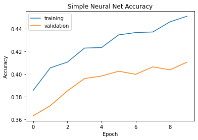

```python
snn_model.plot_acc("Simple Neural Net Accuracy")
```

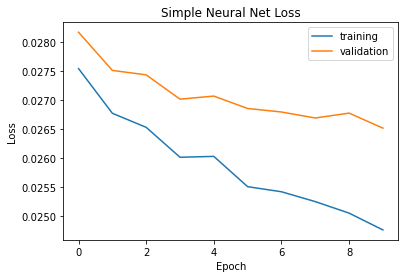

```python
snn_model.plot_loss('Simple Neural Net Loss')
```

Here we can see that in the first few iterations the validation accuracy was improving in the same manner as the training one. But at around the fourth epoch they started diverging. This can be seen in both plots, and indicates that we are overfitting the training data.

### LeNet

After estabilishing our baseline we decided to the LeNet convolutional model to see if some improvement could be made

```python
from models import LeNet
```

```python
lenet_model = CIFAR10TrainingModel(model=LeNet(),
                             learning_rate=1e-3,
                             optimizer=optim.Adam,
                             loss_fn=nn.CrossEntropyLoss())
lenet_model.load_and_transform_data(transform_list=transforms.Compose([
    transforms.ToTensor(),
    transforms.Normalize((0.4915, 0.4823, 0.4468),
                         (0.2470, 0.2435, 0.2616))
]))
```

```
Files already downloaded and verified
```

```python
lenet_model.model
```

```
LeNet(
  (conv1): Conv2d(3, 16, kernel_size=(3, 3), stride=(1, 1), padding=(1, 1))
  (conv2): Conv2d(16, 32, kernel_size=(3, 3), stride=(1, 1), padding=(1, 1))
  (conv3): Conv2d(32, 64, kernel_size=(3, 3), stride=(1, 1), padding=(1, 1))
  (fc1): Linear(in_features=1024, out_features=500, bias=True)
  (dropout1): Dropout(p=0.5, inplace=False)
  (fc2): Linear(in_features=500, out_features=10, bias=True)
)
```

```python
%%time
lenet_model.train(number_of_epochs=10,
                  filepath='../model/lenet_final.pth',
                  save=True)
```

```
Epoch:   1 Training Acc: 0.549 Training Loss: 0.0195 Validation Acc: 0.537 Validation Loss: 0.0198
Epoch:   2 Training Acc: 0.628 Training Loss: 0.0161 Validation Acc: 0.598 Validation Loss: 0.0172
Epoch:   3 Training Acc: 0.687 Training Loss: 0.0139 Validation Acc: 0.643 Validation Loss: 0.0156
Epoch:   4 Training Acc: 0.709 Training Loss: 0.0129 Validation Acc: 0.663 Validation Loss: 0.015
Epoch:   5 Training Acc: 0.76 Training Loss: 0.0108 Validation Acc: 0.695 Validation Loss: 0.0137
Epoch:   6 Training Acc: 0.79 Training Loss: 0.0096 Validation Acc: 0.707 Validation Loss: 0.0133
Epoch:   7 Training Acc: 0.815 Training Loss: 0.00825 Validation Acc: 0.717 Validation Loss: 0.0128
Epoch:   8 Training Acc: 0.82 Training Loss: 0.00797 Validation Acc: 0.714 Validation Loss: 0.0133
Epoch:   9 Training Acc: 0.857 Training Loss: 0.00663 Validation Acc: 0.732 Validation Loss: 0.0126
Epoch:  10 Training Acc: 0.872 Training Loss: 0.00593 Validation Acc: 0.731 Validation Loss: 0.0128
CPU times: total: 39min 22s
Wall time: 6min 34s
```

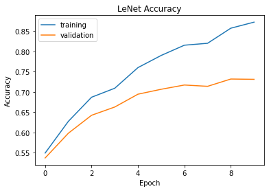

```python
lenet_model.plot_acc('LeNet Accuracy')
```

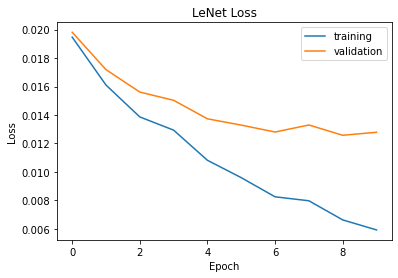

```python
lenet_model.plot_loss('LeNet Loss')
```

Comparing the perfomance of the LeNet model with our baseline, we first note that by the first iteration this model was already better than the baseline at the last iteration. That is, here we started with around 55% accuracy on the validation set, while the last iteration on the baseline barely passed 40% on the same set.

Nevertheless, this model also had the same problem, overfitting. After the fourth iteration the curves started diverging, and our validation accuracy improved at a much slower rate, reaching 73% accuracy after 10 iterations, with a 87% accuracy on the training set.

### LeNet with data augmentation

To prevent overfitting we decided to explore the data augmentation technique. The exact transformations can be seen in the next cell. But the main idea is to generate more images for training by injecting some form of random noisy transformation that keeps the data recognizable.

```python
lenet_aug_model = CIFAR10TrainingModel(model=LeNet(),
                             learning_rate=1e-3,
                             optimizer=optim.Adam,
                             loss_fn=nn.CrossEntropyLoss())
lenet_aug_model.load_and_transform_data(transform_list=transforms.Compose([
        transforms.RandomHorizontalFlip(),
        transforms.RandomAffine(0, shear=10, scale=(0.8,1.2)),
        transforms.ColorJitter(brightness=1, contrast=1, saturation=1),
        transforms.ToTensor(),
        transforms.Normalize((0.4915, 0.4823, 0.4468),
                             (0.2470, 0.2435, 0.2616))
]))
```

```
Files already downloaded and verified
```

```python
%%time
lenet_aug_model.train(number_of_epochs=10,
                      filepath='../model/lenet_aug_final.pth',
                      save=True)
```

```
Epoch:   1 Training Acc: 0.371 Training Loss: 0.0269 Validation Acc: 0.368 Validation Loss: 0.027
Epoch:   2 Training Acc: 0.443 Training Loss: 0.0241 Validation Acc: 0.442 Validation Loss: 0.0243
Epoch:   3 Training Acc: 0.484 Training Loss: 0.0226 Validation Acc: 0.477 Validation Loss: 0.0228
Epoch:   4 Training Acc: 0.503 Training Loss: 0.0217 Validation Acc: 0.496 Validation Loss: 0.0221
Epoch:   5 Training Acc: 0.525 Training Loss: 0.0212 Validation Acc: 0.518 Validation Loss: 0.0215
Epoch:   6 Training Acc: 0.55 Training Loss: 0.0198 Validation Acc: 0.533 Validation Loss: 0.0202
Epoch:   7 Training Acc: 0.559 Training Loss: 0.0196 Validation Acc: 0.545 Validation Loss: 0.0201
Epoch:   8 Training Acc: 0.548 Training Loss: 0.0199 Validation Acc: 0.534 Validation Loss: 0.0205
Epoch:   9 Training Acc: 0.59 Training Loss: 0.0182 Validation Acc: 0.575 Validation Loss: 0.0189
Epoch:  10 Training Acc: 0.595 Training Loss: 0.0184 Validation Acc: 0.582 Validation Loss: 0.019
CPU times: total: 1h 6min 14s
Wall time: 11min 3s
```

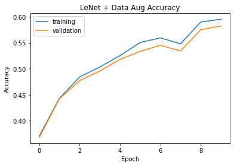

```python
lenet_aug_model.plot_acc('LeNet + Data Aug Accuracy')
```

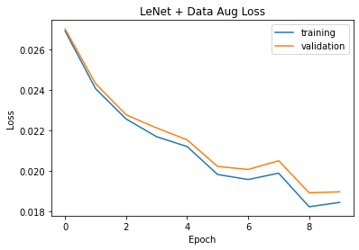

```python
lenet_aug_model.plot_loss('LeNet + Data Aug Loss')
```

Here we can see that despite the LeNet model with data augmentation having a lower accuracy in the beginning, the validation curve follows the training one much more closely. After that we decided to train the model for more iterations, to see if this generalization effect kept going.

```python
%%time
lenet_aug_model.train(number_of_epochs=10,
                      filepath='../model/lenet_aug_final2.pth',
                      save=True)
```

```
Epoch:  11 Training Acc: 0.601 Training Loss: 0.0178 Validation Acc: 0.572 Validation Loss: 0.0187
Epoch:  12 Training Acc: 0.608 Training Loss: 0.0173 Validation Acc: 0.586 Validation Loss: 0.0181
Epoch:  13 Training Acc: 0.581 Training Loss: 0.0188 Validation Acc: 0.569 Validation Loss: 0.0196
Epoch:  14 Training Acc: 0.609 Training Loss: 0.0171 Validation Acc: 0.589 Validation Loss: 0.0178
Epoch:  15 Training Acc: 0.618 Training Loss: 0.0171 Validation Acc: 0.599 Validation Loss: 0.0182
Epoch:  16 Training Acc: 0.62 Training Loss: 0.0168 Validation Acc: 0.6 Validation Loss: 0.0177
Epoch:  17 Training Acc: 0.633 Training Loss: 0.0162 Validation Acc: 0.613 Validation Loss: 0.0171
Epoch:  18 Training Acc: 0.642 Training Loss: 0.0161 Validation Acc: 0.623 Validation Loss: 0.0169
Epoch:  19 Training Acc: 0.644 Training Loss: 0.016 Validation Acc: 0.62 Validation Loss: 0.0172
Epoch:  20 Training Acc: 0.63 Training Loss: 0.0165 Validation Acc: 0.611 Validation Loss: 0.0173
CPU times: total: 1h 6min
Wall time: 11min
```

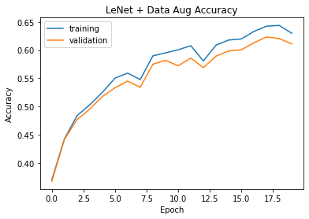

```python
lenet_aug_model.plot_acc('LeNet + Data Aug Accuracy')
```

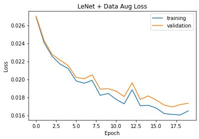

```python
lenet_aug_model.plot_loss('LeNet + Data Aug Loss')
```

The previous graphs show that the training was still generalizing well. But here we saw a different problem, that is, the network was not being able to increase it's training accuracy effectively. This could also indicate some form of local minima for the loss function. Hence we decided to keep training the network to see if the pattern kept going.

```python
%%time
lenet_aug_model.train(number_of_epochs=10,
                      filepath='../model/lenet_aug_final3.pth',
                      save=True)
```

```
Epoch:  21 Training Acc: 0.64 Training Loss: 0.0159 Validation Acc: 0.623 Validation Loss: 0.0172
Epoch:  22 Training Acc: 0.648 Training Loss: 0.0157 Validation Acc: 0.635 Validation Loss: 0.0166
Epoch:  23 Training Acc: 0.64 Training Loss: 0.016 Validation Acc: 0.616 Validation Loss: 0.0172
Epoch:  24 Training Acc: 0.638 Training Loss: 0.0161 Validation Acc: 0.619 Validation Loss: 0.0172
Epoch:  25 Training Acc: 0.64 Training Loss: 0.0161 Validation Acc: 0.622 Validation Loss: 0.0172
Epoch:  26 Training Acc: 0.643 Training Loss: 0.0159 Validation Acc: 0.623 Validation Loss: 0.017
Epoch:  27 Training Acc: 0.641 Training Loss: 0.0158 Validation Acc: 0.623 Validation Loss: 0.0171
Epoch:  28 Training Acc: 0.656 Training Loss: 0.0155 Validation Acc: 0.628 Validation Loss: 0.0167
Epoch:  29 Training Acc: 0.645 Training Loss: 0.0157 Validation Acc: 0.62 Validation Loss: 0.0169
Epoch:  30 Training Acc: 0.661 Training Loss: 0.0152 Validation Acc: 0.635 Validation Loss: 0.0164
CPU times: total: 1h 6min 2s
Wall time: 11min
```

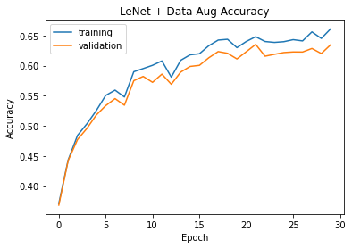

```python
lenet_aug_model.plot_acc('LeNet + Data Aug Accuracy')
```

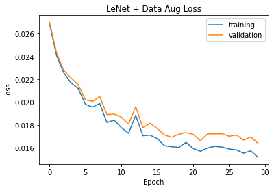

```python
lenet_aug_model.plot_loss('LeNet + Data Aug Loss')
```

By further training the LeNet model with data augmentation we saw that something was preventing the model from increasing it's accuracy on the training set. And while data augmentation proved usefull for increasing the model generalization to the validation set, it also prevented the model from reaching a higher accuracy on the training set. Hence the LeNet model without data augmentation reached a higher accuracy on the validation set.

### Transfer Learning

After the problem with data augmentation in the LeNet model we decided to try something different and explore transfer learning. PyTorch makes it easy to get the weights for built-in models. Hence, we decided to experiment with modifying the AlexNet model to classify images in the Cifar10 dataset.

The AlexNet model was trainined on the ImageNet dataset and famously won the ImageNet Large Scale Visual Recognition Challenge in 2012 by a large margin. The main difference with the previous is the sheer scale of the model. It's number of parameters dwarf's the previouly trained ones.

This number of parameters poses a great chalenge for training. It's much more computationaly expensive to train the model. To remedy this we can freeze a part of the network with previously trained weights, here in another dataset, and make small tweaks in the model to fit a new dataset.

But even after fixating the majority of the parameters in the network our current computational setup was unable to train the model. Each epoch of training was taking longer than 1 hour. This made tweaking our implementation quite hard. And we decided to focus on the other models of the project.

Nevertheless, the implementation is working, and with further exploration we believe that it could achieve a much higher generalization than the other models.

Therefore we present here the overfitting test for the implementation, and show the previous aborted results.

```python
from torchvision.models import AlexNet_Weights
from torchvision import models
alex_net = models.alexnet(AlexNet_Weights)
# Here we fix the features that will not be trained
for param in alex_net.features.parameters():
    param.requires_grad = False

# We also need to modify the final layer of the model. To output a 10-d vector instead of a 1000-d one.
n_inputs = alex_net.classifier[6].in_features
last_layer = nn.Linear(n_inputs, 10)
alex_net.classifier[6] = last_layer
alex_net_model = CIFAR10TrainingModel(model=alex_net,
                                      learning_rate=1e-4,
                                      optimizer=optim.Adam,
                                      loss_fn=nn.CrossEntropyLoss())

alex_net_model.load_and_transform_data(transform_list=transforms.Compose([
    # And resize the input to what AlexNet was trained on
    transforms.Resize((224, 224)),
    transforms.ToTensor(),
    transforms.Normalize((0.4915, 0.4823, 0.4468),
                         (0.2470, 0.2435, 0.2616))
]))

n_epochs = 5
alex_net_model.overfit_single_batch(n_epochs)
```

```
Files already downloaded and verified
Epoch:   1 Training Acc: 0.46 Training Loss: 0.0351
Epoch:   2 Training Acc: 0.8 Training Loss: 0.0253
Epoch:   3 Training Acc: 0.85 Training Loss: 0.0182
Epoch:   4 Training Acc: 0.89 Training Loss: 0.0126
Epoch:   5 Training Acc: 0.98 Training Loss: 0.00815
```

```python
# results from a previous - aborted - execution of the alex net exploration
# %%time
# alex_net_training_loss_hist = []
# alex_net_training_acc_hist = []
# alex_net_val_acc_hist = []

# training_loop(model=alex_net_model,
#               n_epochs=alex_net_epochs,
#               optimizer=alex_net_optimizer,
#               loss_fn=alex_net_loss_fn,
#               train_loader=train_loader,
#               val_loader=val_loader,
#               training_loss_hist=alex_net_training_loss_hist,
#               training_acc_hist=alex_net_training_acc_hist,
#               val_acc_hist=alex_net_val_acc_hist)
# Just this execution took more than 5 hours
# Epoch: 0, Loss: 1.865588, Train Acc: 0.428250, Val Acc: 0.420200
# Epoch: 1, Loss: 1.419102, Train Acc: 0.506050, Val Acc: 0.495500
# Epoch: 2, Loss: 1.219046, Train Acc: 0.603300, Val Acc: 0.583500
# Epoch: 3, Loss: 1.084034, Train Acc: 0.624775, Val Acc: 0.597900
# Epoch: 4, Loss: 0.989995, Train Acc: 0.677425, Val Acc: 0.644600
# Epoch: 5, Loss: 0.927115, Train Acc: 0.689050, Val Acc: 0.649500
```

### Model selection and test accuracy

In terms of the model selection we decided to base our decidion on the accuracy over the validation set. The main discussion was if the generalization found by training the LeNet model with data augmentation could be a better fit for unseen data. But since it's accuracy on the validation set was still significant lower than wihout data augmentation. We decided to do it without.

```python
test_set = datasets.CIFAR10(data_path,
                            train=False,
                            download=True,
                            transform=transforms.Compose([
                                transforms.ToTensor(),
                                transforms.Normalize((0.4915, 0.4823, 0.4468),
                                                     (0.2470, 0.2435, 0.2616))]))
test_loader = torch.utils.data.DataLoader(test_set, batch_size=64, shuffle=False)
```

```
Files already downloaded and verified
```

```python
test_acc, test_loss = lenet_model.calc_acc_and_loss(test_loader)
test_acc, test_loss
```

```
(0.7332, 0.012815934190154076)
```

And with this approach we found 73% accuracy on the test set, that was untouched since the beginning of the exploration

### Classifying images from urls

To further investigate the network perfomance we created a method to classify images based on urls. It's use is interesting, even though not scientific rigorous

```python
from PIL import Image
import requests
```

```python
dog_url = 'https://images.unsplash.com/photo-1587402092301-725e37c70fd8?ixlib=rb-1.2.1&ixid' \
          '=MnwxMjA3fDB8MHxzZWFyY2h8MXx8Y3V0ZSUyMGRvZ3N8ZW58MHx8MHx8&w=1000&q=80 '
```

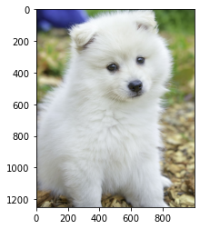

```python
response = requests.get(dog_url, stream=True)
img = Image.open(response.raw)
plt.imshow(img)
```

```python
lenet_model.prediction_from_url(dog_url)
```

```
'dog'
```

### Conclusion

We explored explored different models for the problem of image classification into the classes defined in the Cifar10 dataset.

We first estabilished a baseline using a simple neural network, achieving around 40% accuracy on the validation set. The training, however, was overfitting the training set, thus preventing further epochs from increasing the accuracy.

After that we used the LeNet model and achieved an accuracy of around 70%. But the problem of overfitting remained an issue.

We then tried using transfer learning by modifying AlexNet. This, however, proved to be computationaly unfeasible for our setup.

After this we settled on using the LeNet model without data augmentation for the test dataset. And by using it we achieved 73% accuracy.

### References

- https://pytorch.org/
- https://www.manning.com/books/deep-learning-with-pytorch
- https://www.udemy.com/course/pytorch-for-deep-learning-and-computer-vision/